# pset3_steiner

erika steiner

2025-05-02

In this problem set, we continue analyzing the FTP program, again interpreting beliefs about the time limit as the treatment variable. The goal will be to estimate the effect of a perceived time limit on employment and welfare receipt, this time using a difference-in-differences approach. All data and documentation can be found on Canvas under Problem Set 1.

1. *Find the means of quarterly employment for each quarter from 10 quarters prior to RA to 19 quarters following RA (recall from the documentation that the quarter of random assignment, which would naturally be designated as quarter 0, is actually denoted as quarter 1). Tabulate the number of observations that contribute to each of those means.*

Quarterly Employment Means

| Quarter | Mean | N |
| --- | --- | --- |
| bfr.q10 | 0.0000000 | 1149 |
| bfr.q09 | 0.0687554 | 1149 |
| bfr.q08 | 0.1627502 | 1149 |
| bfr.q07 | 0.2375979 | 1149 |
| bfr.q06 | 0.2497824 | 1149 |
| bfr.q05 | 0.2489121 | 1149 |
| bfr.q04 | 0.2419495 | 1149 |
| bfr.q03 | 0.2489121 | 1149 |
| bfr.q02 | 0.2619669 | 1149 |
| bfr.q01 | 0.3028721 | 1149 |
| postr.q00 | 0.3159269 | 1149 |
| postr.q01 | 0.3472585 | 1149 |
| postr.q02 | 0.3977372 | 1149 |
| postr.q03 | 0.4099217 | 1149 |
| postr.q04 | 0.3951262 | 1149 |
| postr.q05 | 0.4194952 | 1149 |
| postr.q06 | 0.4577894 | 1149 |
| postr.q07 | 0.4873803 | 1149 |
| postr.q08 | 0.4795474 | 1149 |
| postr.q09 | 0.4821584 | 1149 |
| postr.q10 | 0.4847694 | 1149 |
| postr.q11 | 0.4882507 | 1149 |
| postr.q12 | 0.4917319 | 1149 |
| postr.q13 | 0.4986945 | 1149 |
| postr.q14 | 0.5004352 | 1149 |
| postr.q15 | 0.4978242 | 1149 |
| postr.q16 | 0.5152306 | 1149 |
| postr.q17 | 0.5117493 | 1149 |
| postr.q18 | 0.5221932 | 1149 |
| postr.q19 | 0.5228365 | 832 |

1. *Continued: What is the longest pre-period that you could analyze, ensuring that you have data for everyone in the sample? The longest post-period? Refer to this as the balanced sample period.*

There are 1149 people who responded to the survey question about time limits. All pre-randomization quarters include 1149 non-NA observations, as do all post-randomization quarters except for Quarter 19 (postr.q19 aka empq20).The balanced sample period is thus from 10 quarters prior to RA to 18 quarters following RA.

2. *Reconfigure the data so you have one record per person per quarter. Compute mean employment rates by treatment status, before and after treatment. Treatment status is TLyes; the date of random assignment divides the sample period into before and after (consider the period of random assignment itself to be “after”).*

Quarterly Employment by Treatment Status

| Quarter | Control Mean | Treatment Mean | Control N | Treatment N |
| --- | --- | --- | --- | --- |
| bfr.q10 | 0.0000000 | 0.0000000 | 483 | 666 |
| bfr.q09 | 0.0703934 | 0.0675676 | 483 | 666 |
| bfr.q08 | 0.1262940 | 0.1891892 | 483 | 666 |
| bfr.q07 | 0.2111801 | 0.2567568 | 483 | 666 |
| bfr.q06 | 0.2298137 | 0.2642643 | 483 | 666 |
| bfr.q05 | 0.2339545 | 0.2597598 | 483 | 666 |
| bfr.q04 | 0.2339545 | 0.2477477 | 483 | 666 |
| bfr.q03 | 0.2401656 | 0.2552553 | 483 | 666 |
| bfr.q02 | 0.2608696 | 0.2627628 | 483 | 666 |
| bfr.q01 | 0.2898551 | 0.3123123 | 483 | 666 |
| postr.q00 | 0.2960663 | 0.3303303 | 483 | 666 |
| postr.q01 | 0.3126294 | 0.3723724 | 483 | 666 |
| postr.q02 | 0.3519669 | 0.4309309 | 483 | 666 |
| postr.q03 | 0.3643892 | 0.4429429 | 483 | 666 |
| postr.q04 | 0.3519669 | 0.4264264 | 483 | 666 |
| postr.q05 | 0.3788820 | 0.4489489 | 483 | 666 |
| postr.q06 | 0.4057971 | 0.4954955 | 483 | 666 |
| postr.q07 | 0.4347826 | 0.5255255 | 483 | 666 |
| postr.q08 | 0.4016563 | 0.5360360 | 483 | 666 |
| postr.q09 | 0.4223602 | 0.5255255 | 483 | 666 |
| postr.q10 | 0.4368530 | 0.5195195 | 483 | 666 |
| postr.q11 | 0.4368530 | 0.5255255 | 483 | 666 |
| postr.q12 | 0.4306418 | 0.5360360 | 483 | 666 |
| postr.q13 | 0.4347826 | 0.5450450 | 483 | 666 |
| postr.q14 | 0.4554865 | 0.5330330 | 483 | 666 |
| postr.q15 | 0.4699793 | 0.5180180 | 483 | 666 |
| postr.q16 | 0.4658385 | 0.5510511 | 483 | 666 |
| postr.q17 | 0.4906832 | 0.5270270 | 483 | 666 |
| postr.q18 | 0.5031056 | 0.5360360 | 483 | 666 |

2. *Continued: Were employment rates similar between the treatment and control groups prior to treatment?*

Prior to treatment (emppq10:emppq1), the employment rates between the treatment and control groups are similar. If we run a two-sample t-test, as done below, we cannot reject the null hypothesis that the true difference in means between the treatment and control groups is equal to 0.

```
##
##  Welch Two Sample t-test
##
## data:  pre_mean by TLyes
## t = -0.50872, df = 17.919, p-value = 0.6172
## alternative hypothesis: true difference in means between group 0 and group 1 is not equal to 0
## 95 percent confidence interval:
##  -0.11244212  0.06861506
## sample estimates:
## mean in group 0 mean in group 1
##       0.1896480       0.2115616
```

3. *(a) Run a DD regression. The dependent variable should be quarterly employment status, and the explanatory variables should include person dummies, quarter dummies, and an interaction between TLyes and a post-treatment dummy. Be sure to restrict attention to the balanced sample period.*

```
## The variables 'TLyes' and 'post_dummy' have been removed because of collinearity (see $collin.var).
```

```
## OLS estimation, Dep. Var.: employment_status
## Observations: 33,321
## Fixed-effects: sampleid: 1,149,  quarter: 29
## Standard-errors: Heteroskedasticity-robust
##                  Estimate Std. Error t value        Pr(>|t|)
## TLyes:post_dummy 0.056039   0.008849 6.33314 0.0000000002434 ***
## ... 2 variables were removed because of collinearity (TLyes and post_dummy)
## ---
## Signif. codes:  0 '***' 0.001 '**' 0.01 '*' 0.05 '.' 0.1 ' ' 1
## RMSE: 0.385913     Adj. R2: 0.337617
##                  Within R2: 0.001159
```

3. *(b) Now run the same regression, clustering the standard errors by sampleid*

```
## The variables 'TLyes' and 'post_dummy' have been removed because of collinearity (see $collin.var).
```

```
## OLS estimation, Dep. Var.: employment_status
## Observations: 33,321
## Fixed-effects: sampleid: 1,149,  quarter: 29
## Standard-errors: Clustered (sampleid)
##                  Estimate Std. Error t value  Pr(>|t|)
## TLyes:post_dummy 0.056039   0.018376 3.04962 0.0023438 **
## ... 2 variables were removed because of collinearity (TLyes and post_dummy)
## ---
## Signif. codes:  0 '***' 0.001 '**' 0.01 '*' 0.05 '.' 0.1 ' ' 1
## RMSE: 0.385913     Adj. R2: 0.337617
##                  Within R2: 0.001159
```

3. *(b) Continued: Explain why the standard errors change the way they do. Which standard errors should you report?*

3. *(c) How do you interpret the coefficient on the interaction between TLyes and the post- treatment dummy?*

4. *(a) Construct a test for parallel pre-treatment trends.*

```
## The variables 'TLyes', 'quarterbfr.q02', 'quarterbfr.q03', 'quarterbfr.q04', 'quarterbfr.q05', 'quarterbfr.q06' and 4 others have been removed because of collinearity (see $collin.var).
```

```
## OLS estimation, Dep. Var.: employment_status
## Observations: 11,490
## Fixed-effects: sampleid: 1,149,  quarter: 10
## Standard-errors: Clustered (sampleid)
##                       Estimate Std. Error   t value Pr(>|t|)
## TLyes:quarterbfr.q02 -0.020564   0.023352 -0.880609  0.37871
## TLyes:quarterbfr.q03 -0.007368   0.026583 -0.277153  0.78171
## TLyes:quarterbfr.q04 -0.008664   0.028333 -0.305795  0.75982
## TLyes:quarterbfr.q05  0.003348   0.030527  0.109675  0.91269
## TLyes:quarterbfr.q06  0.011993   0.030707  0.390578  0.69618
## TLyes:quarterbfr.q07  0.023119   0.031189  0.741258  0.45869
## TLyes:quarterbfr.q08  0.040438   0.031080  1.301084  0.19349
## TLyes:quarterbfr.q09 -0.025283   0.029926 -0.844847  0.39837
## TLyes:quarterbfr.q10 -0.022457   0.027395 -0.819761  0.41252
## ... 10 variables were removed because of collinearity (TLyes, quarterbfr.q02 and 8 others [full set in $collin.var])
## ---
## Signif. codes:  0 '***' 0.001 '**' 0.01 '*' 0.05 '.' 0.1 ' ' 1
## RMSE: 0.299162     Adj. R2: 0.382875
##                  Within R2: 0.001093
```

4. *(a) Continued: Do you reject the null hypothesis?*

No! The coefficients of the interactions between the time effects and treatment status are not statistically significant.

4. *(b) Plot the relevant results.*

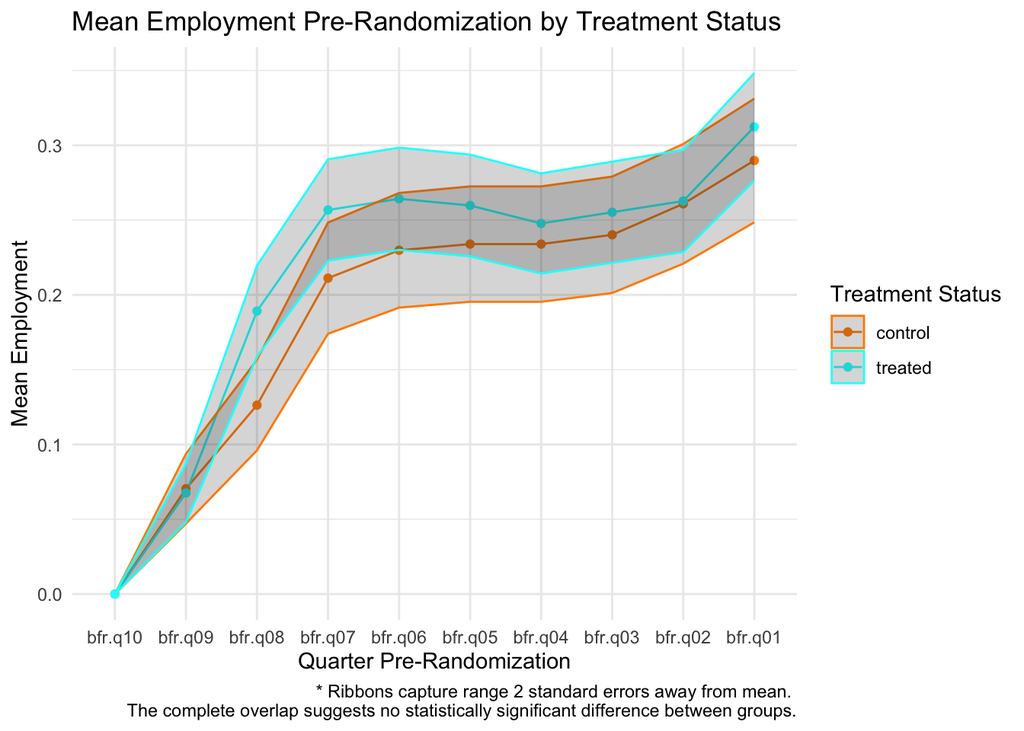

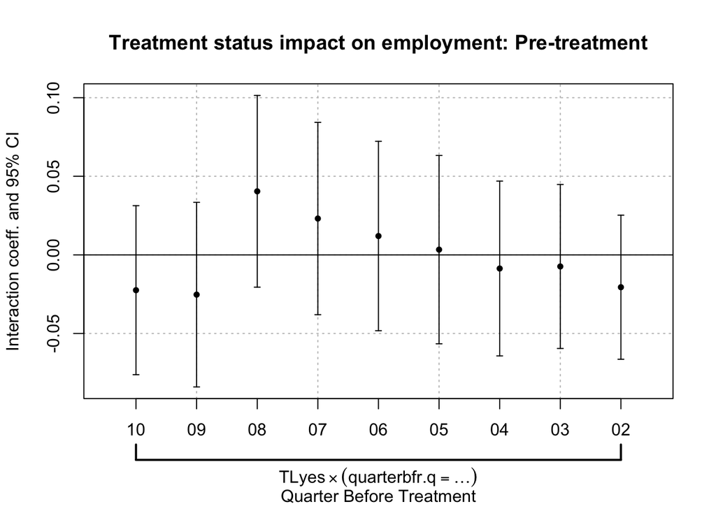

4. *(c) Do your results imply that your estimator identifies the ATT?*

No, these results do not imply that the estimator identifies the ATT. Identification of the ATT requires that there are parallel trends in the untreated outcomes across the entire sample period. However, we cannot know what the untreated outcomes would be for the treated group, as there are no data on the counter-factual.

Failing parallel pre-trends would suggest the identifying assumption fails, but passing (as we have in this case) does not imply that it holds.

5. *Now implement the event-study estimator, that is, estimate period-specific treatment effects that vary freely over the post-treatment period.*

```
## OLS estimation, Dep. Var.: employment_status
## Observations: 33,321
## Fixed-effects: sampleid: 1,149,  quarter: 29
## Standard-errors: Clustered (sampleid)
##                        Estimate Std. Error   t value  Pr(>|t|)
## trt_period::-10:TLyes -0.022457   0.027396 -0.819714 0.4125491
## trt_period::-9:TLyes  -0.025283   0.029928 -0.844798 0.3983994
## trt_period::-8:TLyes   0.040438   0.031082  1.301010 0.1935160
## trt_period::-7:TLyes   0.023119   0.031191  0.741215 0.4587144
## trt_period::-6:TLyes   0.011993   0.030708  0.390556 0.6961982
## trt_period::-5:TLyes   0.003348   0.030529  0.109668 0.9126916
## trt_period::-4:TLyes  -0.008664   0.028334 -0.305777 0.7598296
## trt_period::-3:TLyes  -0.007368   0.026585 -0.277137 0.7817246
## trt_period::-2:TLyes  -0.020564   0.023353 -0.880558 0.3787412
## trt_period::0:TLyes    0.011807   0.025137  0.469697 0.6386606
## trt_period::1:TLyes    0.037286   0.030913  1.206153 0.2280070
## trt_period::2:TLyes    0.056507   0.031738  1.780421 0.0752714 .
## trt_period::3:TLyes    0.056096   0.033345  1.682304 0.0927818 .
## trt_period::4:TLyes    0.052002   0.033136  1.569375 0.1168362
## trt_period::5:TLyes    0.047610   0.035552  1.339156 0.1807849
## trt_period::6:TLyes    0.067241   0.035269  1.906524 0.0568318 .
## trt_period::7:TLyes    0.068286   0.034925  1.955194 0.0508025 .
## trt_period::8:TLyes    0.111922   0.036158  3.095383 0.0020132 **
## trt_period::9:TLyes    0.080708   0.036321  2.222104 0.0264706 *
## trt_period::10:TLyes   0.060209   0.036927  1.630478 0.1032749
## trt_period::11:TLyes   0.066215   0.036925  1.793235 0.0731985 .
## trt_period::12:TLyes   0.082937   0.037087  2.236311 0.0255229 *
## trt_period::13:TLyes   0.087805   0.037383  2.348778 0.0190040 *
## trt_period::14:TLyes   0.055089   0.037369  1.474197 0.1407028
## trt_period::15:TLyes   0.025581   0.037742  0.677807 0.4980306
## trt_period::16:TLyes   0.062755   0.036868  1.702176 0.0889931 .
## trt_period::17:TLyes   0.013887   0.036870  0.376639 0.7065118
## trt_period::18:TLyes   0.010473   0.037237  0.281255 0.7785652
## ---
## Signif. codes:  0 '***' 0.001 '**' 0.01 '*' 0.05 '.' 0.1 ' ' 1
## RMSE: 0.385727     Adj. R2: 0.337699
##                  Within R2: 0.002123
```

5. *Continued: Plot the estimates.*

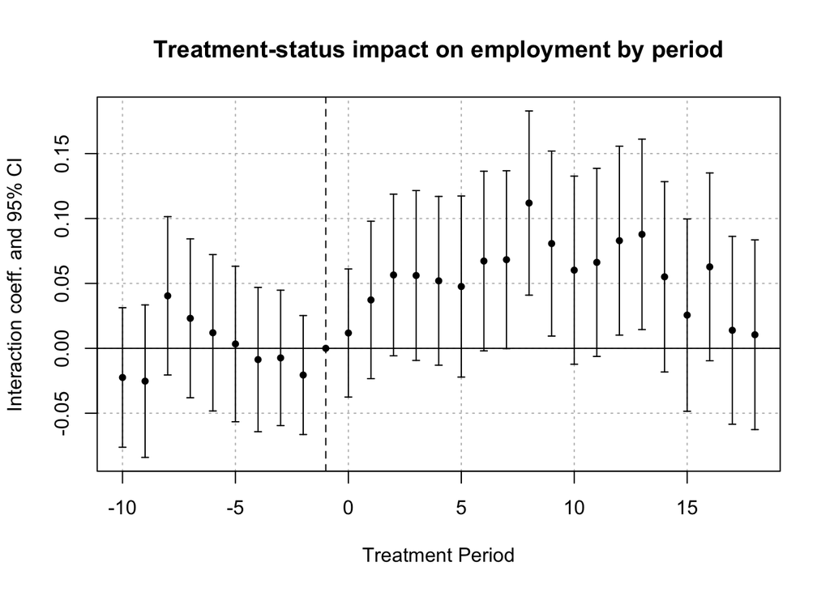

6. *Continued: Are the period-specific estimates significant? If not, does this concern you? Explain.*

While we might expect that some of the periods have slightly larger or smaller coefficients (and thus differ in their significance), it is interesting to note that most of the significant treatment/period interactions occur between 6 and 13 quarters after treatment (peaking at quarter 8). This suggests that there is variance in treatment effect over time, particularly decreasing after period 13.

6. *Compare the mean of the period-specific treatment effects from question 5 to the constant post-treatment effect from question 3.*

Mean Treatment Effect by Model

| Model | Mean Effect |
| --- | --- |
| 3 | 0.0560394 |
| 5 | 0.0554957 |

6. *Continued: Are they similar? How would you test the hypothesis that they are the same?* These mean effects do appear to be very similar. I would conduct the Wald test for pre-test of parallel trends.
7. *So far, we have acted as if all the treatment observations were treated at the same calendar time. In fact, treatment was assigned over a period of four quarters, as can be seen by tabulating the variable rarelqt. Explain briefly why this potentially poses a problem for the analysis above.*

```
##
##   2   3   4
## 366 467 316
```

We know that treatment effects are heterogenous across units and time. Groups randomized into treatment at different quarters are thus experiencing different time effects at each “period” of measured employment. For example, if someone is randomized into treatment in Quarter 2 (approximately August 1994), their employment outcomes in period 8 (8 quarters after randomization) would include the treatment effect and time-specific effects of August 1996 (plus fixed individual effects which are irrelevant here). However the period 8 employment outcomes of someone randomized into treatment in Quarter 4 (approximately February 1995) would reflect the treatment effect and time-specific effects of February 1997. We cannot assume that the time-specific effects of August 1996 and February 1997 are the same; therefore, our analysis above does not accurately identify the average treatment effect. Rather, it conflates treatment effects with some time-specific influences.

8. *To see how important this issue is in practice, re-estimate your event-study model using the Callaway-Sant’anna method. Note that rarelqt = 1 corresponds to 1994.II, that is, April-June*

```
##
## Call:
## att_gt(yname = "employment_status", tname = "cal_quarter", idname = "sampleid",
##     gname = "rarelqt", data = dd8_data, panel = FALSE, control_group = "notyettreated",
##     clustervars = "sampleid", est_method = "dr")
##
## Reference: Callaway, Brantly and Pedro H.C. Sant'Anna.  "Difference-in-Differences with Multiple Time Periods." Journal of Econometrics, Vol. 225, No. 2, pp. 200-230, 2021. <https://doi.org/10.1016/j.jeconom.2020.12.001>, <https://arxiv.org/abs/1803.09015>
##
## Group-Time Average Treatment Effects:
##  Group Time ATT(g,t) Std. Error [95% Simult.  Conf. Band]
##      2   -9       NA         NA            NA          NA
##      2   -8  -0.0103     0.0125       -0.0507      0.0301
##      2   -7  -0.0281     0.0102       -0.0610      0.0049
##      2   -6   0.0721     0.0301       -0.0256      0.1697
##      2   -5   0.0078     0.0265       -0.0782      0.0938
```

[output cut: 94 more lines]

9. *Start by creating a variable showing which observations are first treated in each calendar quarter. Call it racalqt. Tabulate it and comment on the share of observations that is first assigned to treatment in each quarter.*

```
## # A tibble: 4 × 3
##   racalqt           n share
##   <chr>         <int> <dbl>
## 1 1994.III       6119 0.184
## 2 1994.IV        7917 0.238
## 3 1995.I         5278 0.158
## 4 Never Treated 14007 0.420
```

24% of observations are assigned to treatment during the 4th quarter of 1994. 18% are assigned to treatment during the 3rd quarter of 1994, while only 16% are assigned to treatment during the 1st quarter of 1995. 42% are never assigned to treatment.

10. *Calculate ATT(g, t) for each value of g and t = 1994.II to 1997.II. How similar are the estimated effects of treatment for the four groups?*

```
##         term group     time      estimate
## 1   ATT(2,0)     2  1994.II  0.0498842955
## 2   ATT(2,1)     2 1994.III  0.0007174689
## 3   ATT(2,2)     2  1994.IV -0.0315079983
## 4   ATT(2,3)     2   1995.I  0.0082956206
## 5   ATT(2,4)     2  1995.II  0.0601885922
## 6   ATT(2,5)     2 1995.III  0.0190554689
## 7   ATT(2,6)     2  1995.IV  0.0347943834
## 8   ATT(2,7)     2   1996.I -0.0036697968
## 9   ATT(2,8)     2  1996.II  0.0863285351
## 10  ATT(2,9)     2 1996.III  0.1035392933
## 11 ATT(2,10)     2  1996.IV  0.0937858762
## 12 ATT(2,11)     2   1997.I  0.0653498572
## 13 ATT(2,12)     2  1997.II  0.0763003738
## 14  ATT(3,0)     3  1994.II -0.0129835918
```

[output cut: 25 more lines]

11. *Now calculate and plot period-specific treatment effects in units of time relative to the treatment quarter, also known as elapsed time and denoted by e. Do this for e=1,…,8.*
12. *Compare these estimates to those you estimated in question 5. Would you say they are mostly similar, or mostly different? Pay particular attention to the estimates for e=1 to 4.*